# Project1

Samuel Sherman - BlueFlame Energy Finance

01/15/2016

Load and transform the data for the analysis

```r
#
# write a function geteloaddatadf() - you will assign the return value to eloaddf
# in the function do the following
# 1. load the electric load data from elecloaddata.xlsx
# you are not allowed to convert to .csv. Find an appropriate R package that can read .xlsx files and load
# the data in a dataframe called eloaddf. The columns should be dates, kwh, kwVAR
#
# some notes on the data
# the file has 15 min interval data from 1/1/2014 to 12/30/2015
# when you import the data, the first column of your dataset should be dates in POSIXct format
# HINT: use the strptime and as.POSIX.ct functions to form the eloaddf$dates
#
# write a function getweatherdf() - you will assign the return value to weatherdf
# 2. Next load the weather data from NOAA into a data frame weatherdf. The data is in 1874606932872dat.txt
# This is 1 hour interval data for a specific weather station close to
# the location of the site from which electric load data was obtained
#
# you need to use fixed width parsing to read the data into a data frame.
# add a column called dates to the dataframe similar to #1 above
#
# write a funcion getbillsdf() - you will assign the return value to billsdf
# 3. Next load the bill data from billdata.xlsx
# this data is monthly and carefully note the start and end date of each billing period.
# name the fields of the dataframe as
# billdate, billstartdt, billenddt, kwh, mindemandkw, actualdemandkw, custcharge,
# distchrgkw, mttkwh, tbckwh,nugckwh, sbckwh, rggieekwh, deliverykwh,
# totdeliverychrg, supplychrg, totalchrg
#
options(width=120)
setwd("~/Documents/project1")
library('xlsx')
library('gdata')
geteloaddatadf <- function(){
        df = read.xlsx('elecloaddata.xlsx', 1)
        df$DATE = formatC(df$DATE, width = 6, format = "d", flag = "0")
        df$DATE = as.POSIXct(strptime(df$DATE, format = '%m%d%y'))
        names(df)[1] = 'dates'
        names(df)[3] = 'kwh'
        names(df)[4] = 'kwVAR'
        eloaddf = df#[c('dates', 'kwh', 'kwVAR')]
        return(eloaddf)
}


getweatherdf <- function(){
        df2 = read.fwf('1874606932872dat.txt',
                      width=c(6,7,13,4,4,4,4,4,2,2,2,5,3,3,3,3,3,3,3,3,2,5,
                              5,7,6,7,4,4,6,6,6,6,3))
        names(df2) = c('USAF','WBAN','YEARMODAHRMN','DIR','SPD','GUS','CLG','SKC','L',
                     'M','H','VSB','MW','MW','MW','MW','AW','AW','AW','AW','W','TEMP',
                     'DEWP','SLP','ALT','STP','MAX','MIN','PCP01','PCP06','PCP24',
                     'PCPXX','SD')
        df2 = df2[-1,]
        df2$dates = as.POSIXct(strptime(df2[1:19176,3],
                                                  format = '%Y%m%d'))
        weatherdf = df2
        return(weatherdf)
}


getbillsdf <- function(){
        df3 = read.xls('billdata.xlsx', 1)
        names(df3) = c('billdate', 'billstartdt', 'billenddt', 'kwh',
        'mindemandkw','actualdemandkw', 'custcharge','distchrgkw', 'mttkwh',
        'tbckwh','nugckwh', 'sbckwh', 'rggieekwh', 'deliverykwh',
        'totdeliverychrg','supplychrg', 'totalchrg')
        df3$billdate = as.POSIXct(strptime(df3$billdate,
                                                  format = '%m/%d/%y'))
        df3$billstartdt = as.POSIXct(strptime(df3$billstartdt,
                                                  format = '%m/%d/%y'))
        df3$billenddt = as.POSIXct(strptime(df3$billenddt,
                                                  format = '%m/%d/%y'))
        billsdf = df3
        return(billsdf)
}


eloaddf = geteloaddatadf()
billsdf = getbillsdf()
weatherdf = getweatherdf()
```

We now have 3 data sets

1. Electric load data in 15 min interval
2. Weather data in 60 min interval
3. Bill data monthly

Lets do some simple analysis

Display the monthly load profile

```r
# display a summary of the electric load data eloaddf$kwh by summarizing it by year, month and total kwh over each month
# your answer should display 24 rows without the header.
aggregate(eloaddf$kwh, by=list(format(eloaddf$dates, "%Y"),
                               format(eloaddf$dates, "%m")), FUN=sum)
```

```
##    Group.1 Group.2        x
## 1     2014      01 310042.2
## 2     2015      01 309982.4
## 3     2014      02 290141.0
## 4     2015      02 276817.3
## 5     2014      03 300221.0
## 6     2015      03 331338.7
## 7     2014      04 377243.8
## 8     2015      04 360345.0
## 9     2014      05 414222.4
## 10    2015      05 400985.5
## 11    2014      06 429594.5
## 12    2015      06 395711.3
## 13    2014      07 436240.3
## 14    2015      07 408572.9
## 15    2014      08 442178.5
## 16    2015      08 427413.6
## 17    2014      09 435577.5
## 18    2015      09 405078.4
## 19    2014      10 477002.8
## 20    2015      10 494120.3
## 21    2014      11 369605.0
## 22    2015      11 443228.4
## 23    2014      12 341970.5
## 24    2015      12 364985.6
```

Here is the total kwh per month and year.

Now let us do some plotting of the load data

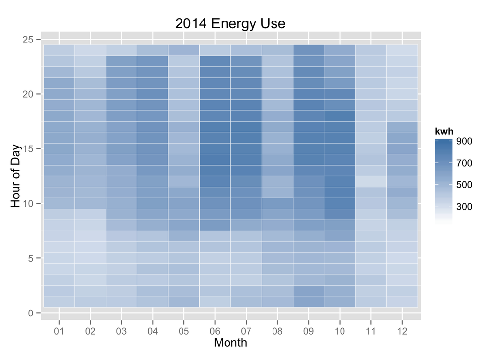

```r
# form a dataframe called eloadhrdf with two columns dates, kwh
# this dataframe sums the 15min kwh in the eloaddf to hourly data
# next create a plot frame with two panels side by side
# On the left panel show a heat map of kwh data for 2014 with x-axis as months and y-axis as hour of the day (1 to 24). use subsetting of the data frame rather than copying the data into yet another data frame
# On the right panel show a heat map of kwh data for 2015 with x-axis as months and y-axis as hour of the day (1 to 24). use subsetting of the data frame rather than copying the data into yet another data frame
library("ggplot2")
library('gridExtra')

#index for group by
index = rep(1:17496, 4)
index = index[order(index)]
index2 = rep(1:17496) * 4
dates = eloaddf$dates[index2]
eloadhrdf = aggregate(eloaddf$kwh, by = list(index), FUN = sum)[2]
eloadhrdf$dates = dates
names(eloadhrdf) = c('kwh','dates')
#hours
eloadhrdf$hour = rep(1:24, 729)

#left plot
(p1 <- ggplot(subset(eloadhrdf, format(eloadhrdf$dates, "%Y") == '2014'),
              aes(format(dates, "%m"), hour, fill = kwh)) +
        geom_tile(colour = "white") + scale_fill_gradient(low = "white",
                                                          high = "steelblue") +
        labs(x = "Month", y = "Hour of Day", title = '2014 Energy Use'))
```

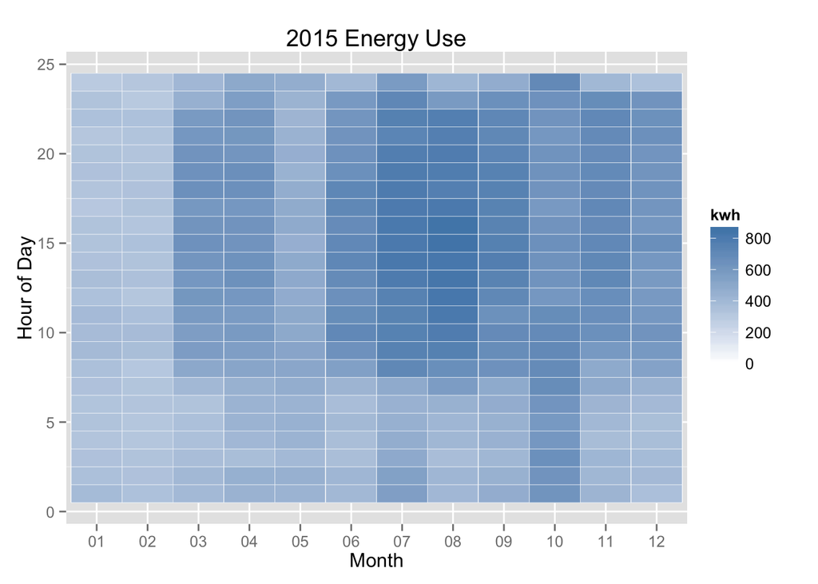

```r
#right plot
(p2 <- ggplot(subset(eloadhrdf, format(eloadhrdf$dates, "%Y") == '2015'),
              aes(format(dates, "%m"), hour, fill = kwh)) +
        geom_tile(colour = "white") + scale_fill_gradient(low = "white",
                                                          high = "steelblue") +
        labs(x = "Month", y = "Hour of Day", title = '2015 Energy Use'))
```

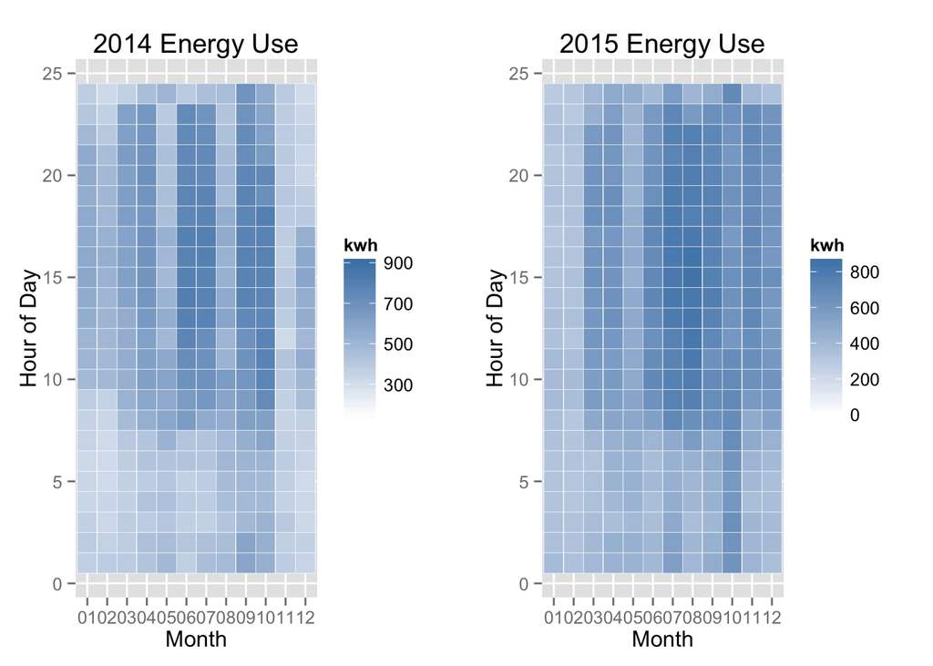

```r
grid.arrange(p1, p2, ncol=2)
```

We plot the weather data using boxplot to explore the variation in temperature graphically

```r
#remove stars as NA
weatherdf2 <- as.data.frame(sapply(weatherdf,sub,pattern='\\*',replacement=NA))
weatherdf2 = weatherdf2[!is.na(weatherdf2$TEMP),]
weatherdf2$dates = as.POSIXct(strptime(weatherdf2$dates[1:18153],
                                                  format = '%Y-%m-%d'))
weatherdf2$TEMP = as.numeric(weatherdf2$TEMP)

#show mean temp per month
aggregate(weatherdf2$TEMP, by = list(format(weatherdf2$dates, "%m")), FUN = mean)
```

```
##    Group.1        x
## 1       01 37.34332
## 2       02 36.72138
## 3       03 45.95718
## 4       04 60.45093
## 5       05 72.59974
## 6       06 79.67381
## 7       07 83.16787
## 8       08 80.65631
## 9       09 77.08339
## 10      10 64.79419
## 11      11 55.14323
## 12      12 53.15230
```

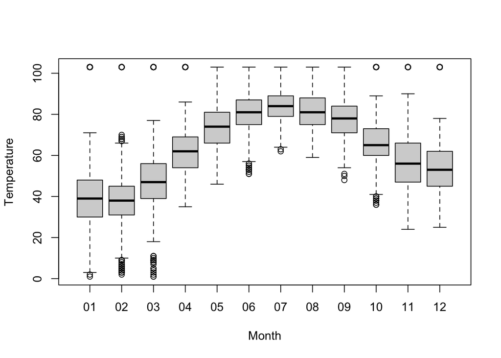

```r
weatherdf$TEMP = as.numeric(weatherdf$TEMP)

#Initial boxplot
bstats <- boxplot(TEMP ~ format(dates, "%m"), data = weatherdf, col = "lightgray",
                  ylab = 'Temperature', xlab = 'Month')
```

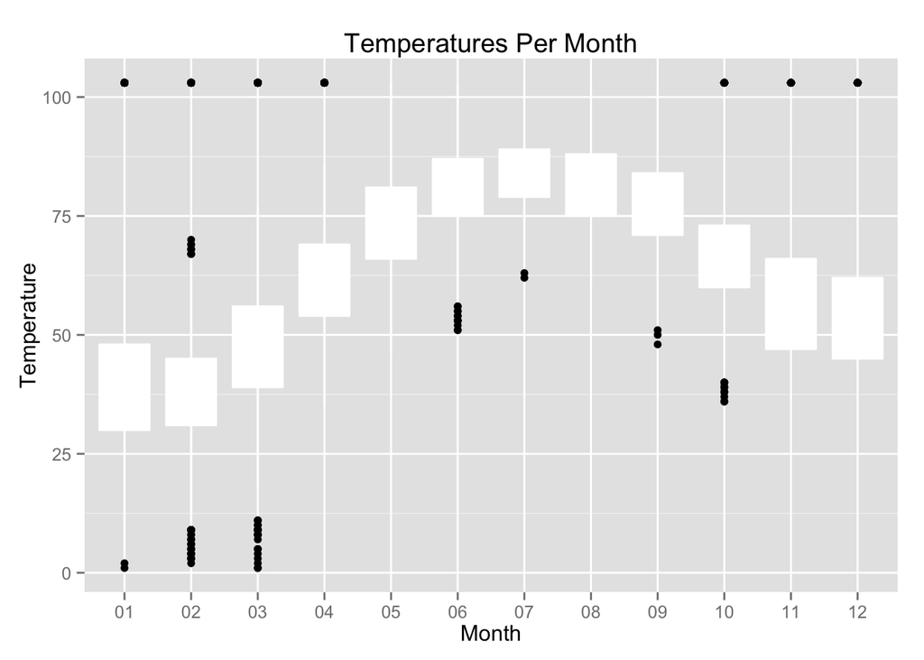

```r
#ggplot2 boxplot
ggplot(weatherdf, aes(format(dates, "%m"), TEMP)) +
        geom_boxplot(colour = "white") +
        labs(x = "Month", title = 'Temperatures Per Month', y = "Temperature")
```

There are clearly some outliers here. However, the ones that appear to stand out the most are the 103 degree temperatures in winter and spring months. Other than that, the temperatures are clearly very cyclical with peaks in the summer and lows in the winter.

We are now ready to build a simple predictive model.

```r
#create a dataframe with hourly interval data inside your function by
# combining selective columns from eloadhrdf and weatherdf
# your dataframe should be called modeldatadf and the columns should be dates, year, month, hrofday, temp, kwh
#
#
# write a simple function called predmodel. the model object should be the return parameter
# pass in the appropriate data frames.
#
# you should fit a GLM with the following specification kwh ~ month + hrofday + temp
# your model should only use 2014 data for your prediction model
#
# use the summary function and display the results of the function

joindf <- function(eloadhrdf, weatherdf){
        weatherdf$hour = format(as.POSIXct(strptime(weatherdf$YEARMODAHRMN[1:19176],
                                                  format = '%Y%m%d%H%M')), '%H')
        eloadhrdf$hour = rep(1:24, 729) #create hour data
        eloadhrdf$hour = eloadhrdf$hour - 1
        eloadhrdf$hour = format(as.POSIXct(strptime(eloadhrdf$hour[1:17496],
                                                    format = '%H')), '%H')
        modeldatadf = merge(eloadhrdf, weatherdf, by = c("dates","hour"),
                            all.x = TRUE)
        modeldatadf = modeldatadf[c('kwh', 'dates', 'hour', 'TEMP')]
        modeldatadf$month = format(modeldatadf$dates, "%m")
        modeldatadf$year = format(modeldatadf$dates, "%Y")
        return(modeldatadf)
}

modeldatadf <- joindf(eloadhrdf, weatherdf)

#removing unlikely outliers
months = list('01','02','03','04','10','11','12')
modeldatadf = subset(modeldatadf, !(TEMP == 103 & month %in% months))



premodel <- function(modeldatadf){
        data = subset(modeldatadf, year == '2014')
        model = glm(kwh ~ month + hour + TEMP, data = data)
        return(model)
}

model = premodel(modeldatadf)
summary(model)
```

```
##
## Call:
## glm(formula = kwh ~ month + hour + TEMP, data = data)
##
## Deviance Residuals:
##     Min       1Q   Median       3Q      Max
## -449.66   -62.40    17.87    76.38   286.82
##
## Coefficients:
##             Estimate Std. Error t value Pr(>|t|)
## (Intercept) 295.4635     7.4359  39.735  < 2e-16 ***
## month02       8.0947     5.3973   1.500 0.133703
## month03     -31.5163     5.3828  -5.855 4.93e-09 ***
## month04      69.8843     5.9406  11.764  < 2e-16 ***
## month05      84.8332     6.5822  12.888  < 2e-16 ***
## month06     109.2471     7.2420  15.085  < 2e-16 ***
## month07      90.8299     7.4439  12.202  < 2e-16 ***
## month08     105.4500     7.2034  14.639  < 2e-16 ***
## month09     121.6617     6.9537  17.496  < 2e-16 ***
## month10     177.1705     6.2477  28.358  < 2e-16 ***
## month11      72.1542     5.5723  12.949  < 2e-16 ***
## month12      23.3482     5.4152   4.312 1.64e-05 ***
## hour01      -14.0878     7.4756  -1.885 0.059528 .
## hour02      -47.8763     7.5425  -6.347 2.29e-10 ***
## hour03      -51.7777     7.5246  -6.881 6.32e-12 ***
## hour04      -75.7608     6.9871 -10.843  < 2e-16 ***
## hour05      -48.9511     7.5088  -6.519 7.44e-11 ***
## hour06      -25.5651     7.5170  -3.401 0.000674 ***
## hour07       36.9583     7.5188   4.915 9.01e-07 ***
## hour08       92.5173     7.5053  12.327  < 2e-16 ***
## hour09      123.4387     7.5307  16.391  < 2e-16 ***
## hour10      123.3423     7.4913  16.465  < 2e-16 ***
## hour11      125.1706     7.4899  16.712  < 2e-16 ***
## hour12      140.3689     7.5189  18.669  < 2e-16 ***
## hour13      151.0137     7.4525  20.263  < 2e-16 ***
## hour14      144.1042     7.5132  19.180  < 2e-16 ***
## hour15      137.8792     7.5568  18.246  < 2e-16 ***
## hour16      137.6904     7.5609  18.211  < 2e-16 ***
## hour17      130.7889     7.5676  17.283  < 2e-16 ***
## hour18      123.8298     7.5931  16.308  < 2e-16 ***
## hour19      116.5217     7.5849  15.362  < 2e-16 ***
## hour20      110.7627     7.5742  14.624  < 2e-16 ***
## hour21       91.1979     7.5769  12.036  < 2e-16 ***
## hour22       48.8010     7.5433   6.469 1.03e-10 ***
## hour23       15.3158     7.5022   2.042 0.041227 *
## TEMP          1.5664     0.1111  14.094  < 2e-16 ***
## ---
## Signif. codes:  0 '***' 0.001 '**' 0.01 '*' 0.05 '.' 0.1 ' ' 1
##
## (Dispersion parameter for gaussian family taken to be 10740.81)
##
##     Null deviance: 215463500  on 9305  degrees of freedom
## Residual deviance:  99567351  on 9270  degrees of freedom
## AIC: 112824
##
## Number of Fisher Scoring iterations: 2
```

First, I removed the ouliers that seemed entirely unlikely. Specifically, these were the 103 degree temperatures in the winter and spring months. Then, I applied a generalized linear model. Month 1 and hour 0 were added into the baseline or intercept. The month of october appears to be most significant, with an increase of 177.2 kwh when true and holding all other variables constant. Additionally, hour 13 also appears to be significant, with an increase of 151 kwh when true and holding all other variables constant.

Application of Gradient Boosted Machine Learning Algorithm

```r
#
# use the dataframe modeldatadf
# split it into training and testing data sets based on 2014 data for training and 2015 data for testing
# Use the GBM algorithm in the caret package in R to train and validate the model.
# You have free reign to display and explain your results graphically
#
#
library(caret)
set.seed(62)
trainDat = subset(modeldatadf, year == '2014')
testDat = subset(modeldatadf, year == '2015')

#Re-create variables as factors
trainDat$month = as.factor(trainDat$month)
trainDat$hour = as.factor(trainDat$hour)
testDat$month = as.factor(testDat$month)
testDat$hour = as.factor(testDat$hour)

#3 k-fold cross validation
fitControl <- trainControl(method = "repeatedcv",number = 3,repeats = 2,
                           verboseIter = TRUE)

#Grid search parameters
gbmGrid <-  expand.grid(interaction.depth = c(1, 3), #tree depth
                        n.trees = c(1000, 5000, 10000), #number of trees
                        shrinkage = c(0.1, 0.01, 0.001), #learning rate
                        n.minobsinnode = 1) #low number here for regressor

set.seed(62)
gbmFit <- train(kwh ~ month + hour + TEMP, data = trainDat,
                 method = "gbm",
                 trControl = fitControl,
                 verbose = FALSE,
                 tuneGrid = gbmGrid)
gbmFit
```

```
## Stochastic Gradient Boosting
##
## 9306 samples
##    5 predictor
##
## No pre-processing
## Resampling: Cross-Validated (3 fold, repeated 2 times)
##
## Summary of sample sizes: 6204, 6205, 6203, 6204, 6204, 6204, ...
##
## Resampling results across tuning parameters:
##
##   shrinkage  interaction.depth  n.trees  RMSE      Rsquared   RMSE SD    Rsquared SD
##   0.001      1                   1000    137.1846  0.2351299  1.0498363  0.005875372
##   0.001      1                   5000    122.9145  0.3871612  0.7040424  0.008023246
##   0.001      1                  10000    115.4213  0.4526617  0.5468993  0.007496104
##   0.001      3                   1000    130.8812  0.3339919  0.9045965  0.009712822
##   0.001      3                   5000    111.1578  0.4878164  0.4031918  0.007330550
##   0.001      3                  10000    105.2728  0.5278469  0.4246539  0.007099259
##   0.010      1                   1000    115.4000  0.4526710  0.5405138  0.007393378
##   0.010      1                   5000    103.9016  0.5342224  0.5711662  0.005675946
##   0.010      1                  10000    103.1125  0.5409077  0.5882569  0.005628222
##   0.010      3                   1000    105.2574  0.5279173  0.4332028  0.006953751
##   0.010      3                   5000    100.9140  0.5602674  0.5444140  0.007275248
##   0.010      3                  10000    101.3585  0.5568268  0.5693780  0.007845115
##   0.100      1                   1000    103.1873  0.5402305  0.5750309  0.005766975
##   0.100      1                   5000    102.6587  0.5450309  0.4830383  0.005299498
##   0.100      1                  10000    102.6567  0.5452049  0.4550407  0.004972579
##   0.100      3                   1000    101.9175  0.5522984  0.5441395  0.007953795
##   0.100      3                   5000    105.5819  0.5249147  0.6666763  0.010080455
##   0.100      3                  10000    108.6425  0.5034663  0.7850261  0.010819959
##
## Tuning parameter 'n.minobsinnode' was held constant at a value of 1
## RMSE was used to select the optimal model using  the smallest value.
## The final values used for the model were n.trees = 5000, interaction.depth = 3, shrinkage = 0.01 and n.minobsinnode = 1.
```

```r
sd(trainDat$kwh)
```

```
## [1] 152.1699
```

The best model had 5000 trees, a tree depth of 3 and shrinkage of 0.01. Examining the standard deviation as a baseline, the model is definetly performing better when comparing with RSME.

Now I plot the residuals

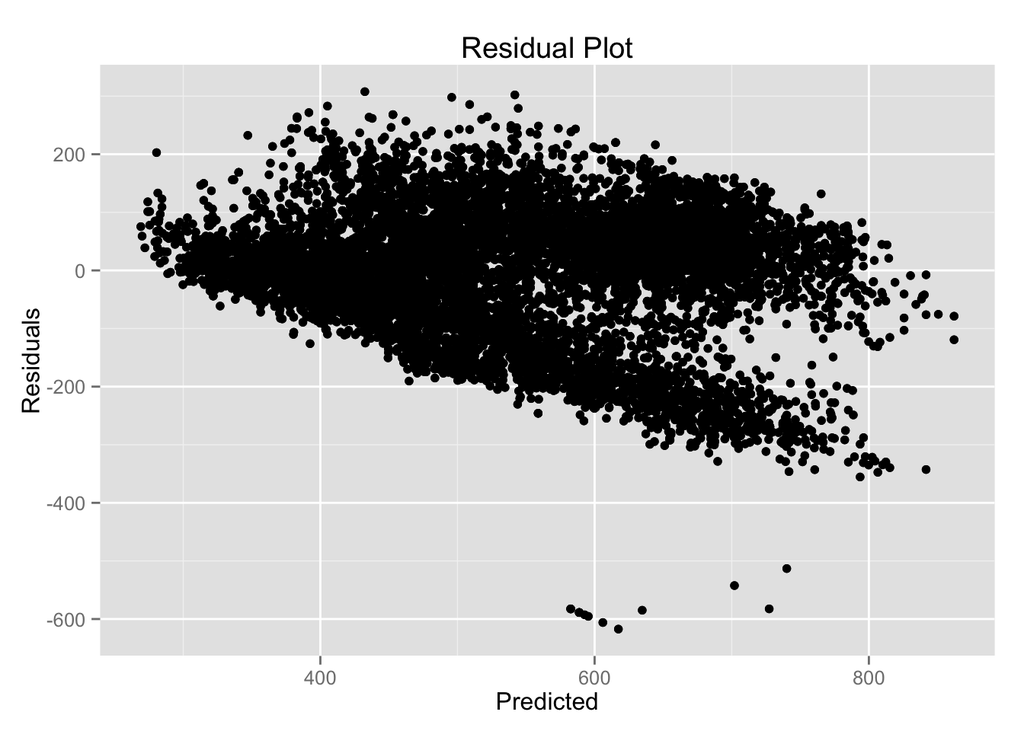

```r
#plot
testDat = na.omit(testDat)
yhat = predict(gbmFit, newdata = testDat[c('month','hour','TEMP')])
y = as.numeric(testDat$kwh)
res = y - yhat
p <- qplot(yhat, res)
p + geom_point() +
        labs(x = "Predicted", title = 'Residual Plot', y = "Residuals")
```

```r
res_sq = res**2
mse = mean(res_sq)
rmse = sqrt(mse)
mse
```

```
## [1] 11972.4
```

```r
rmse
```

```
## [1] 109.4185
```

```r
sd(testDat$kwh)
```

```
## [1] 147.338
```

The model is clearly doing better with lower values for energy use. The residual range is much wider as the kwh usage increases, with the predicted values being larger on average. This would make sense, as compared to the heatmap explored earlier. There were a few months that were inconsistent between the different years. However, the rmse shows a substantial improvement from the baseline standard deviation.

Lets now compare the predicted model for 2015 with the bill data kwh!

```r
#
# run your machine learning model and create a data frame of dates, kwh for 1hr interval data for 2015. note you
# may need to include the last few days of 2014 in your dataset due to the billing dates in January (see billdata.xlsx)
# call your data frame pred2015df.
# now for each of the 12 rows (billing periods) in the billsdf, sum the kwh for the date range in each of the rows from pred2015df for the corresponding start and end of billing in billsdf
# create a resultsdf which has billdate, predkwh (from pred2015df), actualkwh (from billsdf)
# display the results
pred2015df = modeldatadf[9008:dim(modeldatadf)[1],] #index for dates of 2015 billing
pred2015df = na.omit(pred2015df)
pred2015df$predkwh = predict(gbmFit, newdata = pred2015df[c('month','hour','TEMP')])

Func <- function(a, b) with(pred2015df, sum(predkwh[dates >= a & dates <= b]))
Func2 <- function(a, b) with(pred2015df, sum(kwh[dates >= a & dates <= b]))
billsdf$predkwh = apply(billsdf[,2:3], 1, function(x) Func(x[1],x[2]))
billsdf$actualkwh = apply(billsdf[,2:3], 1, function(x) Func2(x[1],x[2]))
resultsdf = billsdf[c('billdate','predkwh','actualkwh')]
resultsdf
```

```
##      billdate  predkwh actualkwh
## 1  2015-01-01 426915.2  407400.7
## 2  2015-02-01 301627.3  293969.8
## 3  2015-03-01 275535.4  312790.7
## 4  2015-04-01 393739.7  377120.4
## 5  2015-05-01 421117.6  402629.4
## 6  2015-06-01 481066.9  445980.3
## 7  2015-07-01 521052.7  469895.1
## 8  2015-08-01 459353.4  436271.1
## 9  2015-09-01 502006.7  453121.6
## 10 2015-10-01 478648.8  496459.3
## 11 2015-11-01 405524.5  467578.6
## 12 2015-12-01 435242.0  449693.6
```

Okay, so here I am not using the kwh from the billsdf because it is not an applicable or appropriate comparision. I should be comparing my out of sample data from the dataset that was used to train the model. The bills data is not consistent with the electricity load data, even in raw format. The mean kwh per 15 min interval of the eloaddf is 132.0676008. This would mean there is about 528 kwh in an hour, 12672 kwh in a day, and 380160 kwh in a month on average. This is already an order of magnitude in difference from what is presented in the bills data, even in raw format without data wrangling or machine learning applied. There is either an error in one of the datasets or the comparison is not legitimate. However, comparing the true rates of kwh from the eload data with the predictions, I can see that these values are, in fact, very close. I still used the appropriate date ranges and billdate from billsdf. The values used here are not seen by the model (out of sample) and I am comparing the true labels to predictions. There appears to be a good balance bewteen bias and variance. The model is flexible enough to provide good estimates for unforseen data and does not have too much variance that would have been overfit to the in-sample data.